# Simulating fisheries with specific selectivity characteristics

Tobias Mildenberger

30/06/2017

## Intro to GitHub and TropFishR.select

There are several ways how to use this package, either you use the build tools in RStudio to build the package yourself, you source all files in the R directory or you install it from GitHub directly with (requires the devtool package):

```r
devtools::install_github("tokami/TropFishR.select")
```

Once the select package is installed you can load it and the main TropFishR package:

```r
require(TropFishR)
require(TropFishR.select)
set.seed(200)
```

## Trawl fleet only

The function *stockSim* allows you to simulate a fish stock with certain life history traits and simulate one to several fishing fleets with specific selectivity characteristics. Important arguments of the function which will be changed in this exercise are: The mean asymptotic length (Linf)

```r
Linf.mu = 93.5
```

The coefficient of variation of Linf

```r
Linf.cv = 0.1
```

The mean growth coefficient

```r
K.mu = 0.2
```

The coefficient of variation of K

```r
K.cv = 0.1
```

The summer point of seasonalised VBGF

```r
ts = 0

t0 = 0.28
```

The amplitude of seasonalised VBGF

```r
C = 0
```

The natural mortality

```r
M = 0.4
```

The time where fishery is active (reduced to one year due to convenience in catch curve analysis, important that the simulation model is in equilibrium)

```r
fished_t = seq(0,35,1/12)
timemax = 35
```

The fishing effort (can be matrix for several fleets)

```r
Etf = 500
```

The catchability coefficient (can be matrix for several fleets)

```r
qtf = 0.001
```

The fishing mortality (or harvest rate, has to be NaN is effort and catchability should be used to estimate F)

```r
harvest_rate = 0.76 ## c(0.5, 0.26) ##
```

The gear types (so far trawl or gillnet, can be a vector for several fleets)

```r
gear_types = c("trawl")
```

The list with parameters defining selectivity curve (more information in functions gillnet and logisticSelect)

```r
sel_list = NULL ## list(mesh_size=18.6, mesh_size1=60,select_dist="gamma",select_p1=3, select_p2=0.5)  # parameters from the tilapia data set
```

L50 parameter of trawl-like selectivity curve

```r
L50 = 55
```

The spread of trawl-like selectivity curve (L75 - L25)

```r
wqs = 7.2 * 2
```

L75 parameter of trawl-like selectivity curve

```r
(L75 = L50 + wqs/2)
```

```
## [1] 62.2
```

The length at first maturity

```r
Lmat = 63.4
```

The model can then be run with these predefined parameters.

```r
ex1 <- stockSim(Linf.mu = Linf.mu,
                Linf.cv = Linf.cv,
                K.mu = K.mu,
                K.cv = K.cv,
                ts = ts,
                C = C,
                M = M,
                Etf = Etf,
                qtf = qtf,
                harvest_rate = harvest_rate,
                gear_types = gear_types,
                sel_list = sel_list,
                L50 = L50,
                wqs = wqs,
                fished_t = fished_t,
                timemax = timemax,
                Lmat = Lmat,
                progressBar = FALSE)
```

### Fishing mortality

In this simulation example there is only one fleet with constant effort

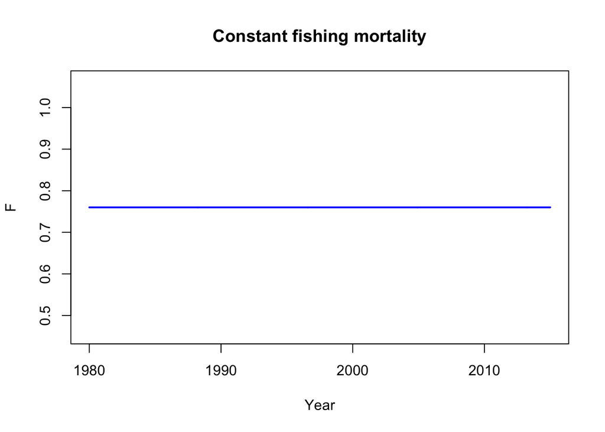

```r
plot(as.Date(ex1$fisheries$fished_years, "%Y-%m-%d"), ex1$fisheries$F,
     type = 'l', main = "Constant fishing mortality",
     xlab = "Year", ylab = "F", lwd=2,col=4)
```

### Selectivity characteristics

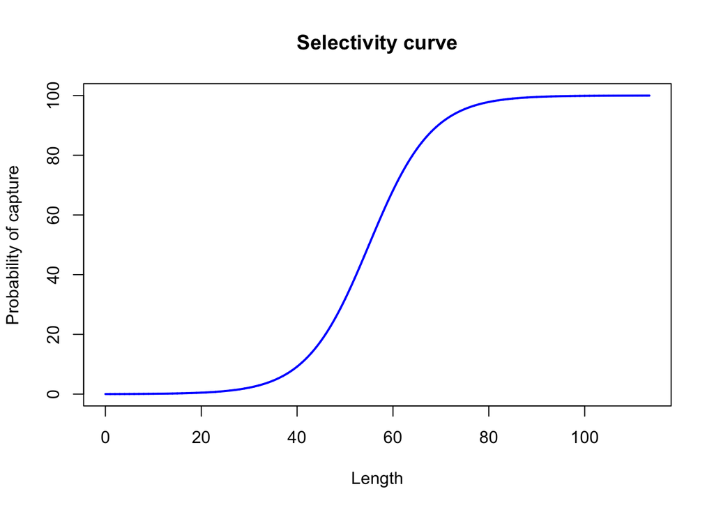

```r
Lt = seq(0,Linf.mu+20,0.01)
pt1 <-  logisticSelect(Lt,L50,wqs) * 100
plot(Lt,pt1,type="l", col = 'blue',lwd=2,
     main = "Selectivity curve",
     xlab = "Length", ylab = "Probability of capture")
```

### Catch curve analysis

```r
lfqdat <- ex1$lfqbin
```

subsample data for 2014

```r
lfqdat$catch <- lfqdat$catch[,which(format(lfqdat$dates, "%Y") %in% "2014")]
lfqdat$dates <- lfqdat$dates[format(lfqdat$dates, "%Y") %in% "2014"]
```

convert data list to lfq class

```r
class(lfqdat) <- "lfq"
```

plot LFQ data

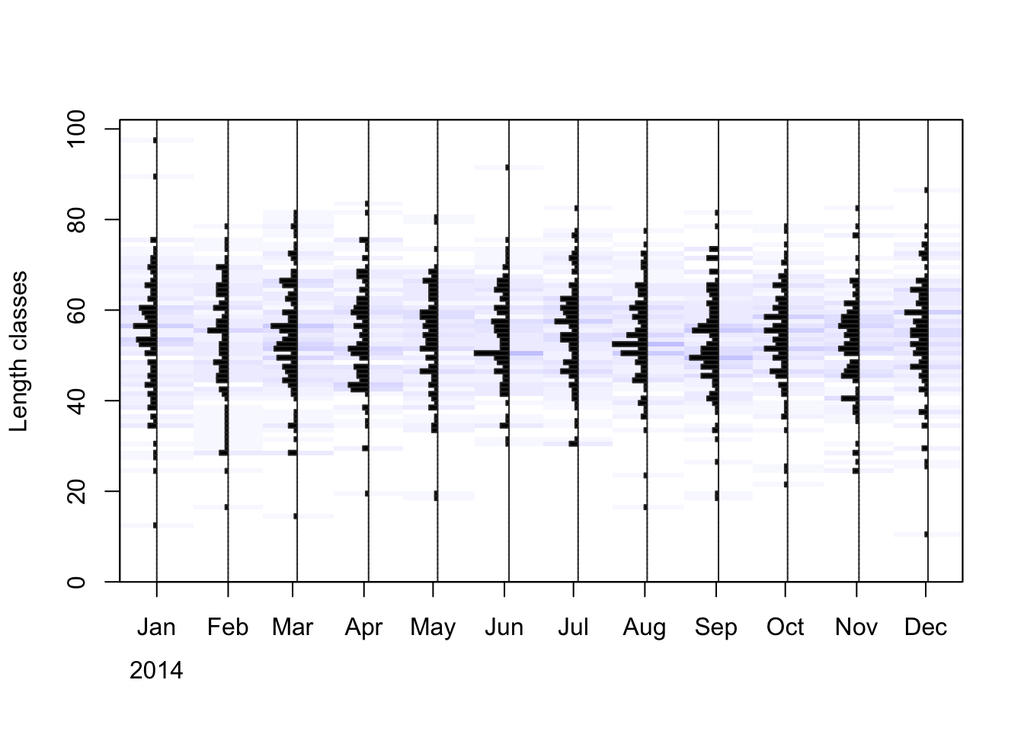

```r
plot(lfqdat, Fname = "catch")
```

modify lfq data and add true growth parameters

```r
ex1mod <- lfqModify(lfqdat,
                    par = list(Linf = Linf.mu, K = K.mu, t0 = t0),
                    vectorise_catch = TRUE, bin_size = 4)
```

apply catch curve analysis

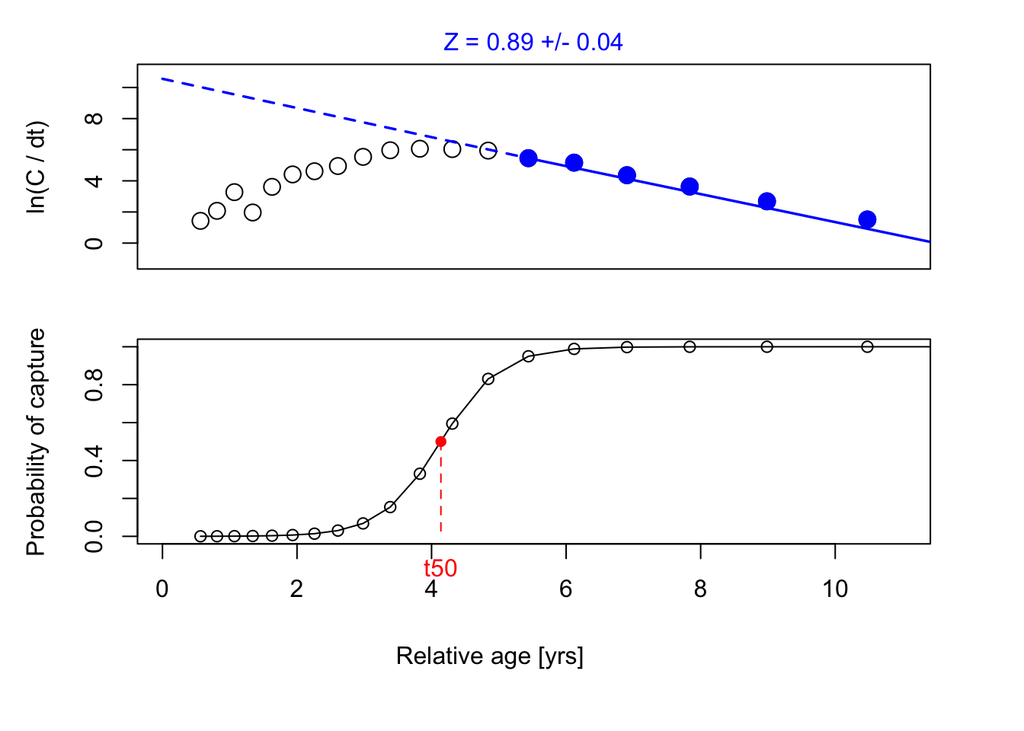

```r
res1 <- catchCurve(ex1mod, reg_int = c(14, 20), calc_ogive = TRUE)
```

compare selectiviy curves

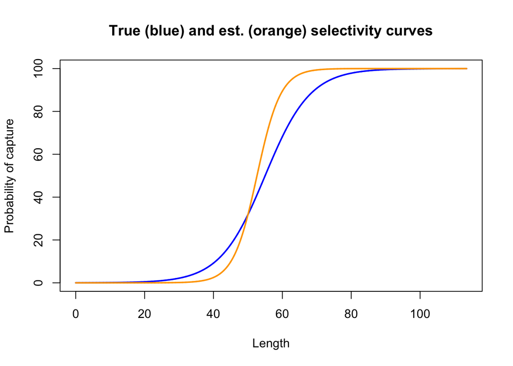

```r
par(mfrow=c(1,1))
plot(Lt,pt1,type="l", col = 'blue',lwd=2,
     main = "True (blue) and est. (orange) selectivity curves",
     xlab = "Length", ylab = "Probability of capture")
lines(Lt, select_ogive(list(selecType = "trawl_ogive", L50 = res1$L50, L75 = res1$L75), Lt)*100,
      col = "orange", lwd = 2)
```

resulting L50 with difference and percentage error

```r
res1$L50
```

```
## [1] 52.63839
```

```r
abs(res1$L50 - L50)
```

```
## [1] 2.361611
```

```r
round(((abs(res1$L50 - L50)) / L50) * 100, 1)
```

```
## [1] 4.3
```

resulting L75 with difference and percentage error

```r
res1$L75
```

```
## [1] 56.42336
```

```r
abs(res1$L75 - L75)
```

```
## [1] 5.776644
```

```r
round(((abs(res1$L75 - L75)) / L75) * 100, 1)
```

```
## [1] 9.3
```

resulting wqs

```r
(res1$L75 - res1$L50) * 2
```

```
## [1] 7.569934
```

## All fleets (trawl + gillnet)

```r
Linf.mu = 93.5
Linf.cv = 0.1
K.mu = 0.2
K.cv = 0.1
t0 = 0.28
ts = 0
C = 0
M = 0.4
fished_t = seq(0,35,1/12)
timemax = 35
# Etf = matrix(rep(c(500,200),each=length(fished_t)),ncol=2, nrow = length(fished_t))
# qtf = 0.001
harvest_rate = c(0.5,0.2/3,0.2/3,0.2/3)
gear_types = c("trawl","gillnet","gillnet","gillnet")
sel_list1 <- list(mesh_size=1, mesh_size1=NULL, select_dist="normal_fixed", select_p1=94.7, select_p2=13.67)
sel_list2 <- list(mesh_size=1, mesh_size1=NULL, select_dist="normal_fixed", select_p1=101.8, select_p2=14.7)
sel_list3 <- list(mesh_size=1, mesh_size1=NULL, select_dist="normal_fixed", select_p1=112, select_p2=16.17)
sel_list = list(NULL,sel_list1, sel_list2, sel_list3)
```

L50 parameter of trawl-like selectivity curve

```r
L50 = 55
```

The spread of trawl-like selectivity curve (L75 - L25)

```r
wqs = 7.2 * 2
```

L75 parameter of trawl-like selectivity curve

```r
(L75 = L50 + wqs/2)
```

```
## [1] 62.2
```

The length at first maturity

```r
Lmat = 63.4
```

The model can then be run with these predefined parameters.

```r
ex2 <- stockSim(Linf.mu = Linf.mu,
                Linf.cv = Linf.cv,
                K.mu = K.mu,
                K.cv = K.cv,
                ts = ts,
                C = C,
                M = M,
                harvest_rate = harvest_rate,
                gear_types = gear_types,
                sel_list = sel_list,
                L50 = L50,
                wqs = wqs,
                fished_t = fished_t,
                timemax = timemax,
                progressBar = FALSE)
```

### Fishing mortality

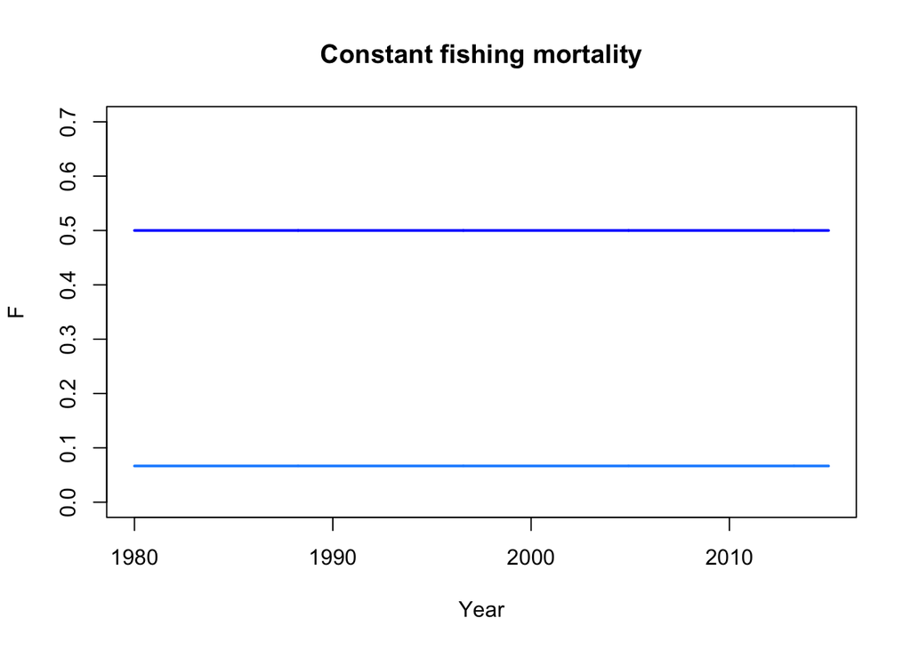

```r
plot(as.Date(ex2$fisheries$fished_years, "%Y-%m-%d"), ex2$fisheries$F[,1],
     type = 'l', main = "Constant fishing mortality",
     xlab = "Year", ylab = "F", lwd=2, ylim = c(0,0.7), col=4)
lines(as.Date(ex2$fisheries$fished_years, "%Y-%m-%d"),
      ex2$fisheries$F[,2], lwd=2, col="dodgerblue1")
```

### Selectivity characteristics

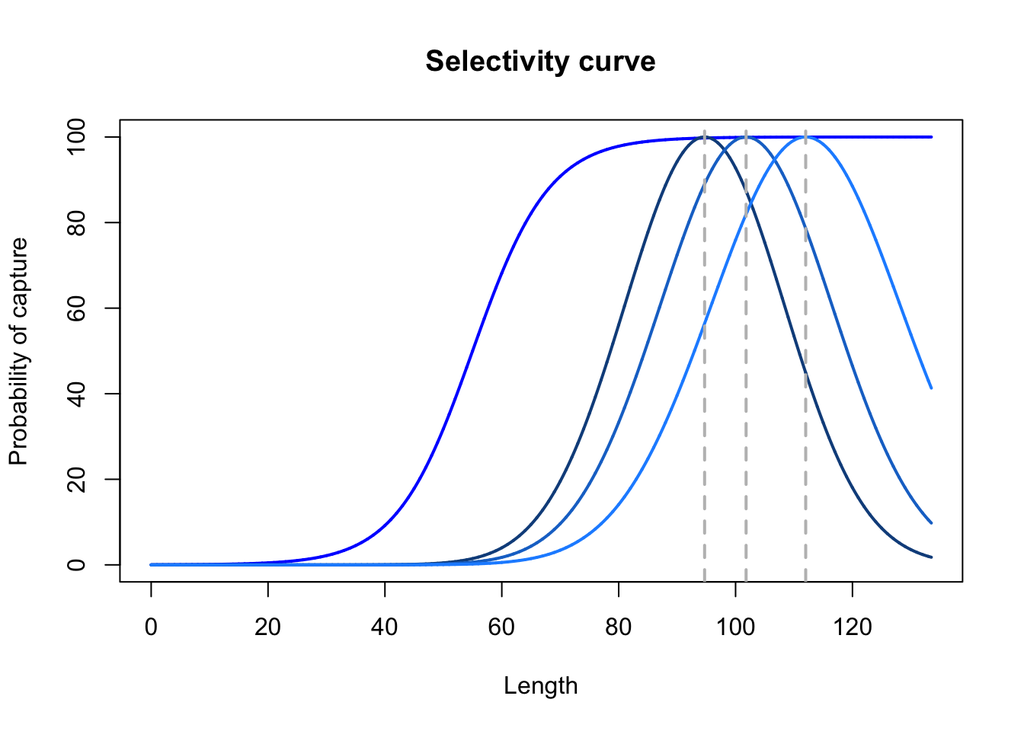

```r
# sel_list1 <- list(mesh_size=186, mesh_size1=60, select_dist="lognormal", select_p1=3.7, select_p2=0.5)
# sel_list2 <- list(mesh_size=200, mesh_size1=60, select_dist="lognormal", select_p1=3.7, select_p2=0.5)
# sel_list3 <- list(mesh_size=220, mesh_size1=60, select_dist="lognormal", select_p1=3.7, select_p2=0.5)

sel_list1 <- list(mesh_size=1, mesh_size1=NULL, select_dist="normal_fixed", select_p1=94.7, select_p2=13.67)
sel_list2 <- list(mesh_size=1, mesh_size1=NULL, select_dist="normal_fixed", select_p1=101.8, select_p2=14.7)
sel_list3 <- list(mesh_size=1, mesh_size1=NULL, select_dist="normal_fixed", select_p1=112, select_p2=16.17)


Lt = seq(0,Linf.mu+40,0.01)
pt1 <-  logisticSelect(Lt,L50,wqs) * 100
pt2a <-  do.call(TropFishR.select::gillnet,c(sel_list1,list(Lt=Lt))) * 100
pt2b <-  do.call(TropFishR.select::gillnet,c(sel_list2,list(Lt=Lt))) * 100
pt2c <-  do.call(TropFishR.select::gillnet,c(sel_list3,list(Lt=Lt))) * 100
plot(Lt,pt1,type="l", col = 'blue',lwd=2,
     main = "Selectivity curve",
     xlab = "Length", ylab = "Probability of capture")
lines(Lt, pt2a, lwd=2, col="dodgerblue4")
lines(Lt, pt2b, lwd=2, col="dodgerblue3")
lines(Lt, pt2c, lwd=2, col="dodgerblue1")

abline(v=94.7, col='grey',lwd=2,lty=2)
abline(v=101.8, col='grey',lwd=2,lty=2)
abline(v=112, col='grey',lwd=2,lty=2)
```

### Catch curve analysis

```r
lfqdat <- ex2$lfqbin
```

subsample data for 2014

```r
lfqdat$catch <- lfqdat$catch[,which(format(lfqdat$dates, "%Y") %in% "2014")]
lfqdat$dates <- lfqdat$dates[format(lfqdat$dates, "%Y") %in% "2014"]
```

convert data list to lfq class

```r
class(lfqdat) <- "lfq"
```

plot LFQ data

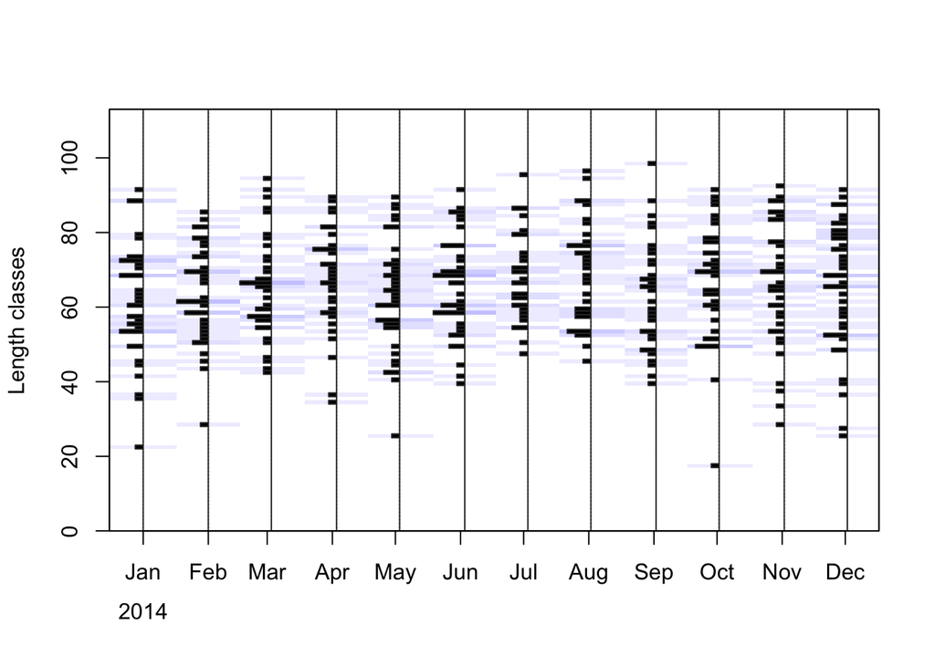

```r
plot(lfqdat, Fname = "catch")
```

modify lfq data and add true growth parameters

```r
ex2mod <- lfqModify(lfqdat,
                    par = list(Linf = Linf.mu, K = K.mu, t0 = t0),
                    vectorise_catch = TRUE, bin_size = 4)
```

apply catch curve analysis

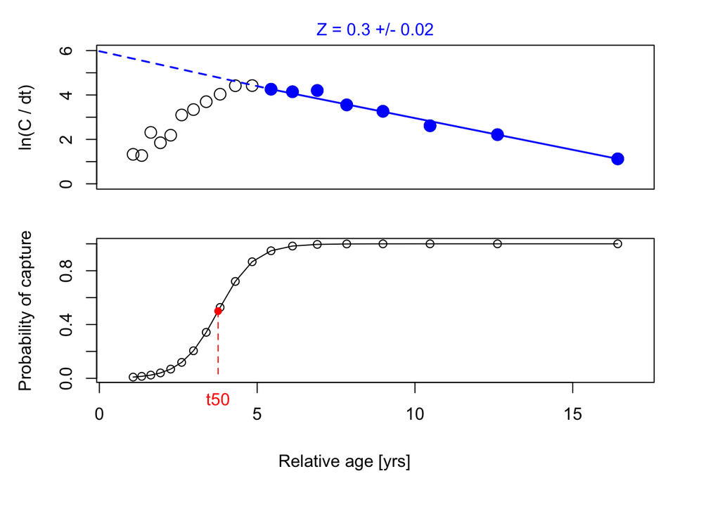

```r
res2 <- catchCurve(ex2mod, reg_int = c(12, 19), calc_ogive = TRUE)
```

compare selectiviy curves

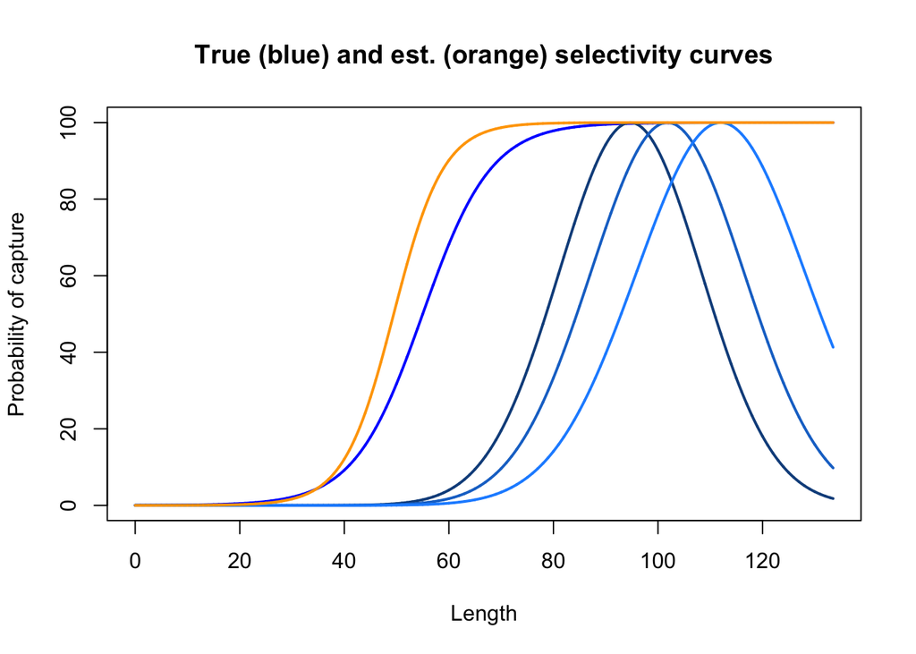

```r
par(mfrow=c(1,1))
plot(Lt,pt1,type="l", col = 'blue',lwd=2,
     main = "True (blue) and est. (orange) selectivity curves",
     xlab = "Length", ylab = "Probability of capture")
lines(Lt, pt2a, lwd=2, col="dodgerblue4")
lines(Lt, pt2b, lwd=2, col="dodgerblue3")
lines(Lt, pt2c, lwd=2, col="dodgerblue1")
lines(Lt, select_ogive(list(selecType = "trawl_ogive", L50 = res2$L50, L75 = res2$L75), Lt)*100,
      col = "orange", lwd = 2)
```

I define effective selectivity curves here as the combined selectivity curve of multiple gears with different selectivity curves in a multi-fleet multi-gear sceanrio. There might be a proper definition of this selectivity, but I don’t have time to search the web for this term.

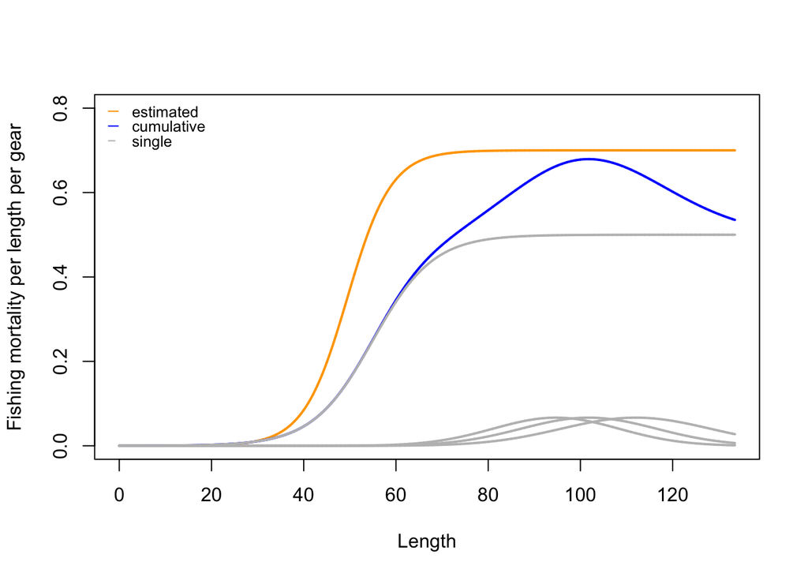

```r
ptAll <- (pt1/100 * 0.5 + pt2a/100 * (0.2/3) + pt2b/100 * (0.2/3) + pt2c/100 * (0.2/3))
plot(Lt,ptAll, type="n", col = 'blue',lwd=2, ylim = c(0,0.8),
     xlab = "Length", ylab = "Fishing mortality per length per gear")
lines(Lt, select_ogive(list(selecType = "trawl_ogive", L50 = res2$L50, L75 = res2$L75), Lt)*0.7,
      col = "orange", lwd = 2)
lines(Lt,ptAll, col = 'blue',lwd=2)
## draw selectivities from single gears
lines(Lt, pt1/100* 0.5, lwd=2, col="grey",lty=2)
lines(Lt, pt2a/100 * (0.2/3), lwd=2, col="grey",lty=2)
lines(Lt, pt2b/100 * (0.2/3), lwd=2, col="grey",lty=2)
lines(Lt, pt2c/100 * (0.2/3), lwd=2, col="grey",lty=2)
legend("topleft", legend = c('estimated','cumulative','single'),
       col=c('orange','blue','grey'),lty=c(1,1,2), bty='n',
       cex = 0.8, y.intersp = 0.8, seg.len = 0.7)
```

Now, the difficulty is to evaluate the difference in these two selection ogives. The max of the blue curve should also reach 0.7, I suspect that this error is due to the rounding inaccuracy. resulting L50

```r
res2$L50
```

```
## [1] 49.44873
```

resulting L75

```r
res2$L75
```

```
## [1] 54.68589
```

resulting wqs

```r
(res2$L75 - res2$L50) * 2
```

```
## [1] 10.47432
```

This needs some proper testing, but on first glance, no pattern of the decreasing selectivity pattern for large individuals in the catch curve. Ascending part of the selectivity curve is relatively good represented. It might make more sense to run the catch curve with a smaller bin size to detect pattern on a finer scale in particular for larger length classes (possible to give general recommnedation for bin size in catch curve? - the smaller the better, always?). Aternative ways to test the behaviour and precision of the method:

- increase cv of Linf and K
- widen spawning window
- change relation of different gears (harvest_rate or with effort)